# Girard estimation

Use `sample_growth_tb` to estimate tail parameters and extreme quantiles with Girard’s method. The sample consists of firm growth rates for 2019–20 that meet the conditions on beginning-of-period sales, firm age, and industry.

## 1 Estimation assuming $\tau = 0$

### 1.1 Function definitions

```r
library(tidyverse)
library(pins)
library(hrbrthemes)
theme_set(theme_ipsum(base_size = 12, axis_title_size = 13))
board <- board_folder("../Zipf_law_board_replicate_simulation")
```

**Sample settings**

Load `sample_growth_tb` and calculate firm age `age` as the beginning year extracted from period label `year` minus establishment year `birth_year`. For 2019–20 growth (`g_20_19`), select observations meeting the following conditions.

- Beginning-of-period sales `pre_sale` of at least $4.0 \times 10^4$  
  With sales measured in thousands of yen, this corresponds to at least 40 million yen.
- Beginning-of-period firm age of at least five
- The first two digits of industry code `ind_class` are 01–61 or 68–92
- Finite growth `growth`

**Preparing to calculate the Hill estimator**

Let $X_{(1)}, X_{(2)}, \ldots, X_{(n)}$ denote growth `growth` sorted in descending order. Calculate `hill_est` by dividing the cumulative sum by rank $i$.

$$H(i) = \frac{1}{i}\sum_{j=1}^{i}j\log\left(\frac{X_{(j)}}{X_{(j+1)}}\right) = \frac{1}{i}\sum_{j=1}^{i}\log\left(\frac{X_{(j)}}{X_{(i+1)}}\right).$$

In row $i$, `hill_est` is the mean log excess of the largest $i$ observations above the growth threshold at rank $i+1$. When using growth at rank $k_n$ as the threshold, use `hill_est` from row $k_n-1$, namely $H(k_n-1)$.

```r
sample_growth_tb <- board |> pin_read("sample_growth_tb", type = "qs2") |>
  mutate(age = as.numeric(str_c(20, str_sub(year, 6,7))) - birth_year)

sample_tb <- sample_growth_tb |>
  filter(year %in% c("g_20_19"),
         is.finite(growth),
         pre_sale >= 4.0*10^4,
         age >= 5,
         str_sub(ind_class, 1,2) %in% str_pad(c(1:61, 68:92), 2, pad = 0)) |>
  arrange(desc(growth)) |>
  select(growth) |>
  mutate(i_var = 1:n(), n_i_var = n()/i_var, lead = lead(growth)) |>
  mutate(hill_element = i_var*log(growth/lead),
         hill_est = cumsum(hill_element)/i_var)
```

**Definition of the function $\mu_\tau$**

Evaluate the integral for $\tau \neq 0$ using `mu_f()`, switching to `mu_f_tau_0()` when $\tau = 0$. Although the theoretical upper integration limit is infinity, the code performs numerical integration with an upper limit of 10.

$$\mu_\tau(t) = \int_0^\infty \{K_\tau(x+t)-K_\tau(t)\}e^{-x}\,dx, \qquad K_0(y)=\log y, \quad K_\tau(y)=\frac{y^\tau-1}{\tau}\ \ (\tau\neq0).$$

```r
mu_f_tau_0 <- \(t_x) integrate(\(x) (log(x + t_x) - log(t_x))*exp(-x), 0.0, 10)$value
mu_f <- function(tau_x, t_x) {
  if (tau_x == 0) {
    return(mu_f_tau_0(t_x))
  }
  integrate(\(x) ((x + t_x)^{tau_x} - t_x^{tau_x})*exp(-x)/tau_x, 0.0, 10)$value
}
```

### 1.2 Estimating $\alpha = \theta^{-1}$ under $\tau = 0$

**Estimating $\alpha$ with the Hill estimator**

Set the rank threshold to $k_n=\operatorname{round}(0.05n)$. With growth at rank $k_n$, $X_{(k_n)}$, as the threshold, estimate $\alpha=\theta^{-1}$ using `hill_est` from row $k_n-1$ and $\mu_0(t)$ at $t=\log(n/k_n)$. The Hill estimator averages the $k_n-1$ observations above the threshold and assumes $k_n\geq2$.

$$\widehat\alpha = \left\{\frac{H(k_n-1)}{\mu_0(\log(n/k_n))}\right\}^{-1}.$$

```r
n_obs <- sample_tb |> summarise(n_obs = n()) |> pull(n_obs)
k_n <- round(0.05*n_obs) #k_n <- 3*10^3

est_alpha <- (sample_tb$hill_est[k_n - 1]/mu_f_tau_0(t_x = log(n_obs/k_n)))^{-1}
str_c("alpha is ", est_alpha)
```

```
[1] "alpha is 0.446689318009061"
```

**Checking linearity**

Using descending growth rates $X_{(i)}$, create a scatterplot with $\log\log(n/i)$ on the horizontal axis and $\log X_{(i)}$ on the vertical axis.

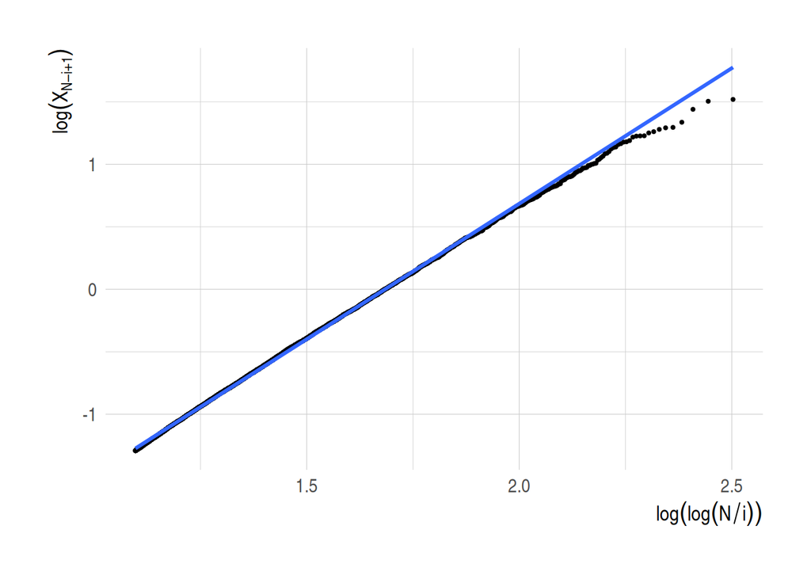

```r
sample_tb |>
  mutate(x_var = log(log(n_i_var)), y_var = log(growth)) |>
  filter(i_var < k_n) |>
ggplot(aes(x_var, y_var)) +
  geom_point(size = 0.7) +
  geom_smooth(method = "lm") +
  labs(
      x = expression(log(log(N / i))),
      y = expression(log (X[N-i+1]))
  ) +
  theme(axis.title = element_text(face = "bold"))
ggsave(filename = "Weibull_linear_relation.png", path = "graph")
```

### 1.3 Estimating extreme quantiles and tail probabilities

**Creating variables**

Set `growth_kn` to growth at rank $k_n$ in descending order, $X_{(k_n)}$, and `est_theta` to the reciprocal of `est_alpha`. Calculate the following columns and save the top $k_n$ observations in `est_quantile_tb`.

- `p_n`: rank-based empirical tail probability $i/n$.
- `tail_growth`: growth relative to the threshold, $X_{(i)}/X_{(k_n)}$.
- `prob_var`: $\log(1/p_n)/\log(n/k_n)$.
- `est_quantile`: $\widehat{x}_{p_n}=X_{(k_n)}\{\log(1/p_n)/\log(n/k_n)\}^{\widehat\theta}$.

Define `est_pn_f()` to calculate tail probabilities using the same threshold and estimated parameters.

$$\widehat p(x)=\exp\left\{\log(k_n/n)\left(\frac{x}{X_{(k_n)}}\right)^{1/\widehat\theta}\right\}.$$

```r
growth_kn <- sample_tb$growth[k_n]
est_theta <- 1/est_alpha

est_quantile_tb <- sample_tb |>
  mutate(p_n = 1/n_i_var,
         tail_growth = growth/growth_kn,
         prob_var = log(1/p_n)/log(n_obs/k_n),
         est_quantile = growth_kn*(log(1/p_n)/log(n_obs/k_n))^est_theta) |>
  select(growth, tail_growth, p_n, prob_var, est_quantile) |>
  slice(1:k_n)

est_pn_f <- \(x) exp(log(k_n/n_obs)*(x/growth_kn)^{1/est_theta})
```

**Visualization**

With observed growth on the horizontal axis and tail probability on the vertical axis, compare empirical tail probabilities `p_n` for the top $k_n$ observations with the curve estimated by `est_pn_f()`. Use a logarithmic vertical scale, displaying growth from 0 to 3 and tail probabilities from $10^{-5}$ to $10^{-1}$.

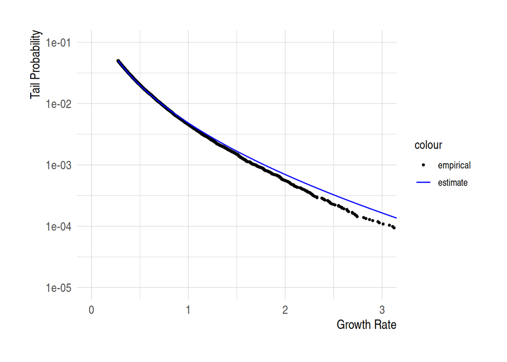

```r
est_quantile_tb |>
ggplot(aes(growth, p_n)) +
  geom_point(aes(color = "empirical"), size = 0.7) +
  geom_function(aes(color = "estimate"), fun = est_pn_f) +
  coord_cartesian(xlim = c(0, 3), ylim = c(10^{-5}, 10^{-1})) +
  scale_y_log10() +
  scale_color_manual(values = c("empirical" = "black", "estimate" = "blue")) +
  labs(
      x = "Growth Rate",
      y = "Tail Probability"
  ) +
  theme(axis.title = element_text(face = "bold"))
ggsave(filename = "Weibull_est_th.png", path = "graph")
```

## 2 Estimating $\tau$

**Definition of `tau_est_f()`**

For a given rank threshold $k_n$, set the second threshold to $k'_n=10k_n$. Generate candidate values of $\tau$ from $-1$ to $2$ in increments of 0.002 (including $\tau=0$), and calculate the following two ratios for each candidate.

$$\frac{\mu_\tau(\log(n/k_n))}{\mu_\tau(\log(n/k'_n))} \qquad\text{and}\qquad \frac{H(k_n-1)}{H(k'_n-1)}.$$

To align the Hill estimator thresholds with $X_{(k_n)}$ and $X_{(k'_n)}$, reference `hill_est` at the threshold rank minus one. Return the candidate that minimizes the absolute difference between the two ratios.

```r
tau_est_f <- \(k_n_x){
  k_n_2_x <- 10*k_n_x
  # Divide integers by 500 to create a grid from -1 to 2 that includes zero exactly.
  tau_seq <- seq(-500L, 1000L) / 500

  mu_ratio <- map_dbl(tau_seq, \(tau_x) mu_f(tau_x, t_x = log(n_obs/k_n_x))/mu_f(tau_x, t_x = log(n_obs/k_n_2_x)))
  Hill_ratio <- sample_tb$hill_est[k_n_x - 1]/sample_tb$hill_est[k_n_2_x - 1]

  tau_seq[which.min(abs(mu_ratio - Hill_ratio))]
}
```

**Threshold-specific $\tau$ estimates and 95% bands**

Estimate $\tau$ at each threshold $k_n=10,20,\ldots,6000$. Calculate the standard error and 95% bands using the following formula.

$$\mathrm{se}(k_n)=\frac{1}{\sqrt{k_n}\{\log\log(n/k_n)-\log\log(n/k'_n)\}}, \qquad \mathrm{CI}(k_n)=\widehat\tau(k_n)\pm1.96\,\mathrm{se}(k_n).$$

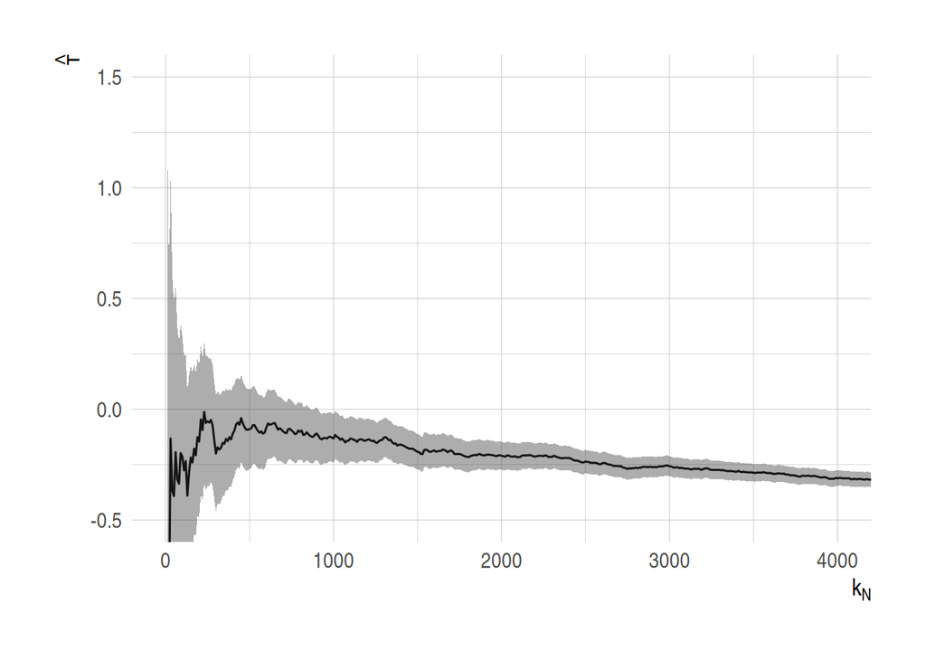

```r
# Add the standard error (se) and lower and upper 95% confidence limits to tau_est_tb alongside tau_est.
tau_est_tb <- tibble(k_n = seq(10, 6000, by = 10)) %>%
  mutate(
    tau_est = map_dbl(k_n, tau_est_f),
    # Calculate k_n_2 (originally k_n_2_x = 10 * k_n_x).
    k_n_2 = 10 * k_n,
    # Calculate the specified standard error.
    se = 1 / (sqrt(k_n) * (log(log(n_obs/k_n)) - log(log(n_obs/k_n_2)))),
    ci_lower = tau_est - 1.96 * se,
    ci_upper = tau_est + 1.96 * se
  )

# Plot: add a confidence ribbon using geom_ribbon().
tau_est_tb %>%
  ggplot(aes(x = k_n)) +
  geom_line(aes(y = tau_est)) +
  geom_ribbon(aes(ymin = ci_lower, ymax = ci_upper), alpha = 0.4) +
  coord_cartesian(xlim = c(0, 4000), ylim = c(-.5, 1.5)) +
  labs(
      x = expression(k[N]),
      y = expression(hat(tau))
  ) +
  theme(axis.title = element_text(face = "bold"))
ggsave(filename = "Girard_est_tau.png", path = "graph")
```